# Forecast Rib Eye

2021-07-08

### Exploratory analysis

USDA reports every week a weighted average price of the rib. This reports covers from 1:30pm friday to the previous friday at the same time.

[interactive chart not shown]

El consumo de cortes fino sigue una estacionalidad muy marcada, principalmente en las compras hechas directamente por individuos a través de autoservicios. Así, el consumo se eleva en la primavera y verano cuando el clima es más cálido y permite las carnes asadas en el exterior, y, en el caso del rib eye, también en el invierno cuando se acostumbra a consumirlo cocinado al horno como prime rib.

[interactive chart not shown]

### SARIMA model estimate

The function **auto.arima** in the forecast package in R identifies the order of the SARIMA model for the rib eye price. Since the numbers of weeks in a year is not constant (52 or 53), we used a fractional period of 365.25/7 and run the auto.arima function.

```r
ribeye_arima0 <- auto.arima(ribeyeTS, stepwise=FALSE, approximation=FALSE)
save(ribeye_arima0, file ="DatosR/Ribeye_arima0.RData")
```

```
## Series: ribeyeTS
## ARIMA(2,1,1)(1,0,0)[52]
##
## Coefficients:
##          ar1      ar2      ma1    sar1
##       1.3876  -0.5712  -0.9712  0.3446
## s.e.  0.0478   0.0474   0.0145  0.0640
##
## sigma^2 estimated as 1269:  log likelihood=-1569.59
## AIC=3149.17   AICc=3149.37   BIC=3167.92
```

```
##        ar1        ar2        ma1       sar1
##  1.3876328 -0.5711874 -0.9712312  0.3445613
```

```
##                    ME     RMSE      MAE        MPE     MAPE      MASE
## Training set 1.810462 35.33849 23.97824 0.04446121 3.025843 0.3142426
##                    ACF1
## Training set 0.02408205
```

The proposed model is
$$(1-1.3876B+0.5712B^2)(1-0.3446B^{52})(1-B)y_t = c + (1-0.9712B)\epsilon_t$$

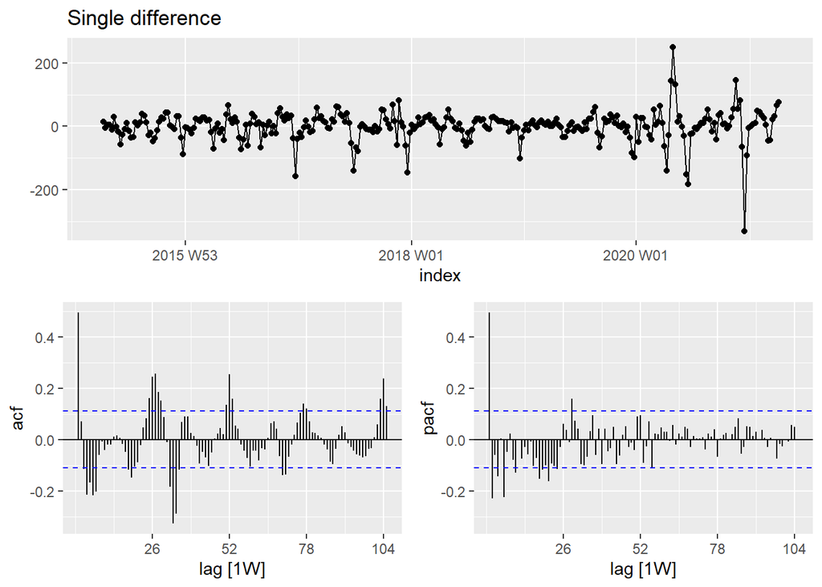

In the autocorrelation function (ACF), we can identify a seasonal MA(1) and a non-seasonal MA(5). And the partial autocorrelation function (PACF) indicates a seasonal AR(1) and a possible non-seasonal autoregressive process of at least order 5.

```r
fit1 <- arima(ribeye$price, order = c(0,1,5),
              seasonal = list(order = c(0,0,1), period = 365.25/7))
fit1
```

```
##
## Call:
## arima(x = ribeye$price, order = c(0, 1, 5), seasonal = list(order = c(0, 0,
##     1), period = 365.25/7))
##
## Coefficients:
##          ma1      ma2      ma3      ma4      ma5    sma1
##       0.4798  -0.1063  -0.4310  -0.5584  -0.2106  0.2571
## s.e.  0.0561   0.0519   0.0509   0.0538   0.0514  0.0636
##
## sigma^2 estimated as 1327:  log likelihood = -1577.29,  aic = 3168.58
```

```r
accuracy(fit1)
```

```
##               ME RMSE MAE MPE MAPE
## Training set NaN  NaN NaN NaN  NaN
```

```r
fit2 <- arima(ribeye$price, order = c(5,1,0),
              seasonal = list(order = c(1,0,0), period = 365.25/7))
fit2
```

```
##
## Call:
## arima(x = ribeye$price, order = c(5, 1, 0), seasonal = list(order = c(1, 0,
##     0), period = 365.25/7))
##
## Coefficients:
##          ar1      ar2      ar3      ar4      ar5    sar1
##       0.5329  -0.1520  -0.0593  -0.1192  -0.0125  0.3616
## s.e.  0.0621   0.0658   0.0663   0.0643   0.0576  0.0673
##
## sigma^2 estimated as 1357:  log likelihood = -1581.87,  aic = 3177.74
```

```r
accuracy(fit2)
```

```
##               ME RMSE MAE MPE MAPE
## Training set NaN  NaN NaN NaN  NaN
```

These models are not better than the one found with the auto.arima function. The residual for this model are shown.

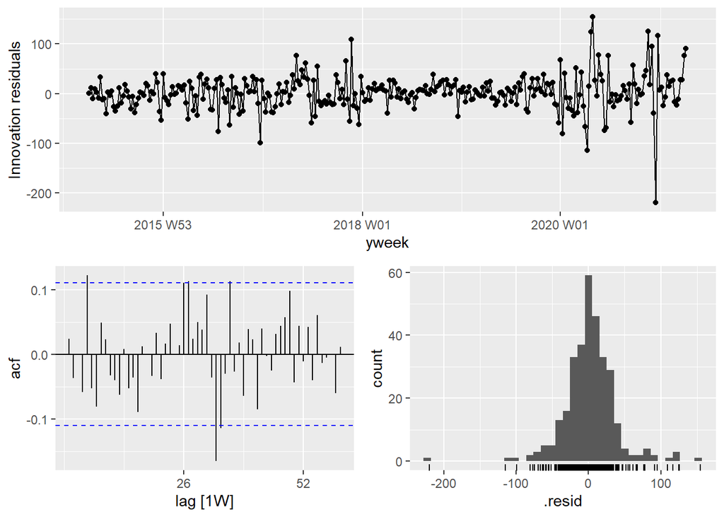

There are few spikes out of the limits, but we can still consider this as white noise. (A test?)

### SARIMA simulation

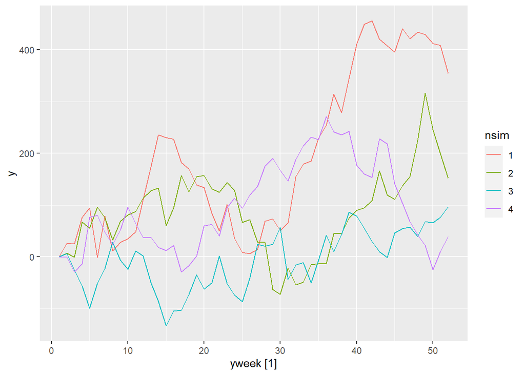

### References

Godahewa, R., Bergmeir, C., Webb, G. I., & Montero-Manso, P. (2020). A strong baseline for weekly time series forecasting. arXiv preprint arXiv:2010.08158.